# Predicting Client’s Bank Term Deposit Subscription

Sean Schilk

10/26/2025

# 1 Introduction

In this project we assume that a set of several candidate models/algorithms have already been developed. The objective is to use various methods to choose the one with the best predictive power to implement in real-world applications.

# 2 Data Set

I’m using a data set provided by Henrique Yamahata on Kaggle called “Bank Marketing”. The data is related with direct marketing campaigns (phone calls) of a Portuguese banking institution.

## 2.1 Variable Descriptions

The variables names in the data set and their variable type are the following:

1. **age**: Age (years)
2. **Job**: type of job (categorical: ‘admin.’, ‘blue-collar’, ‘entrepreneur’, ‘housemaid’, ‘management’, ‘retired’, ‘self-employed’, ‘services’, ‘student’, ‘technician’, ‘unemployed’, ‘unknown’)
3. **Marital** : marital status (categorical: ‘divorced’, ‘married’, ‘single’, ‘unknown’ ; note: ‘divorced’ means divorced or widowed)
4. **Education**: (categorical: ‘basic.4y’, ‘basic.6y’, ‘basic.9y’, ‘high.school’, ‘illiterate’, ‘professional.course’, ‘university.degree’, ‘unknown’)
5. **Default**: has credit in default? (categorical: ‘no’, ‘yes’, ‘unknown’)
6. **Housing**: has housing loan? (categorical: ‘no’, ‘yes’, ‘unknown’)
7. **Loan**: has personal loan? (categorical: ‘no’, ‘yes’, ‘unknown’)
8. **Contact**: contact communication type (categorical: ‘cellular’,‘telephone’)
9. **Month**: last contact month of year (categorical: ‘jan’, ‘feb’, ‘mar’, …, ‘nov’, ‘dec’)
10. **Day_of_week**: last contact day of the week (categorical: ‘mon’,‘tue’,‘wed’,‘thu’,‘fri’)
11. **Duration**: last contact duration, in seconds (numeric).
12. **Campaign**: number of contacts performed during this campaign and for this client (numeric, includes last contact)
13. **Pdays**: number of days that passed by after the client was last contacted from a previous campaign (numeric; 999 means client was not previously contacted)
14. **Previous**: number of contacts performed before this campaign and for this client (numeric)
15. **Poutcome**: outcome of the previous marketing campaign (categorical: ‘failure’,‘nonexistent’,‘success’)
16. **Emp.var.rate**: employment variation rate - quarterly indicator (numeric)
17. **Cons.price.idx**: consumer price index - monthly indicator (numeric)
18. **Cons.conf.idx**: consumer confidence index - monthly indicator (numeric)
19. **Euribor3m**: euribor 3 month rate - daily indicator (numeric)
20. **Nr.employed**: number of employees - quarterly indicator (numeric)
21. **y**: has the client subscribed a term deposit? (binary: ‘yes’, ‘no’)

```r
data <- read.csv("https://sschilk.github.io/MySTA321/bank-additional-full.csv",
                 sep = ";", stringsAsFactors = FALSE)

data.0 = data
data = na.omit(data.0)

set.seed(321)   # ensures reproducibility
data.red <- data[sample(nrow(data), 1000), ] #reduce sample size
data.red$y <- ifelse(data.red$y == "yes", 1, 0)
data.red = na.omit(data.red)
```

## 2.2 Practical Question

The objective of this case study is to build a logistic regression model to predict if the client will subscribe a term deposit using direct marketing campaigns based on phone calls.

## 2.3 Exploratory Data Analysis

We first make the following pairwise scatter plots to inspect the potential issues with predictor variables

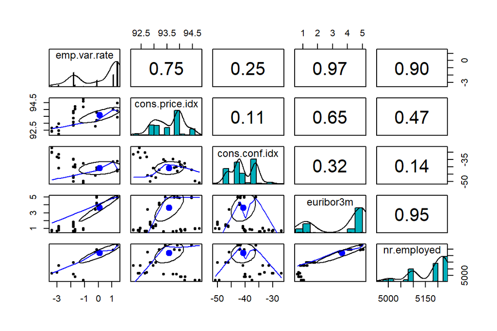

```r
pairs.panels(data.red[, c("emp.var.rate", "cons.price.idx", "cons.conf.idx","euribor3m","nr.employed")],  #Only include cont vars
             method = "pearson", # correlation method
             hist.col = "#00AFBB",
             density = TRUE,  # show density plots
             ellipses = TRUE # show correlation ellipses
             )
```

```r
detach("package:psych", unload = TRUE)
```

From the correlation matrix plot, we can see several patterns in the predictor variables.

- No predictor variables are unimodal. There does not seem to be any significant skewing, so we will not be discretizing any variabls.

# 3 Standizing Numerical Predictor Variables

Since this is a predictive model, we don’t worry about the interpretation of the coefficients. The objective is to identify a model that has the best predictive performance.

```r
data.red$sd.emp.var.rate = (data.red$emp.var.rate-mean(data.red$emp.var.rate))/sd(data.red$emp.var.rate)
data.red$sd.cons.price.idx = (data.red$cons.price.idx-mean(data.red$cons.price.idx))/sd(data.red$cons.price.idx)
data.red$sd.cons.conf.idx = (data.red$cons.conf.idx-mean(data.red$cons.conf.idx))/sd(data.red$cons.conf.idx)
data.red$sd.euribor3m = (data.red$euribor3m-mean(data.red$euribor3m))/sd(data.red$euribor3m)
data.red$sd.nr.employed = (data.red$nr.employed-mean(data.red$nr.employed))/sd(data.red$nr.employed)
## drop the original variables except for the response variable
sd.data.red = data.red[,-(1:20)]
```

If the final model is used for real-time prediction, we need to write a separate function to perform all variable transformations and modifications before feeding it to the model for prediction.

# 4 Data Split - Training and Testing Data

We randomly split the data into two subsets. 80% of the data will be used as training data. We will use the training data to search the candidate models, validate them and identify the final model using the cross-validation method. The 20% of the hold-up sample will be used for assessing the performance of the final model.

```r
## splitting data: 80% training and 20% testing
n <- dim(sd.data.red)[1]
train.n <- round(0.8*n)
train.id <- sample(1:n, train.n, replace = FALSE)
## training and testing data sets
train <- sd.data.red[train.id, ]
test <- sd.data.red[-train.id, ]
```

# 5 Best Model Identification

We will use the full, reduced, and final models obtained based on the step-wise variable selection as the three candidate models.

# 6 Cross-Validation for Model Identification

Since our training data is relatively small, I will use 5-fold cross-validation to ensure the validation data set has enough subscriptions to a term deposit.

```r
## 5-fold cross-validation
k=5
## floor() function must be used to avoid producing NA in the subsequent results
fold.size = floor(dim(train)[1]/k)
## PE vectors for candidate models
PE1 = rep(0,5)
PE2 = rep(0,5)
PE3 = rep(0,5)
for(i in 1:k){
  ## Training and testing folds
  valid.id = (fold.size*(i-1)+1):(fold.size*i)
  valid = train[valid.id, ]
  train.dat = train[-valid.id,]
  ##  full model
  candidate01 = glm(y ~.,
                    family = binomial(link = "logit"),
                    data = train.dat)
  ## reduced model
  candidate03 = glm(y ~ sd.euribor3m,
                    family = binomial(link = "logit"),
                    data = train.dat)
  ##
  candidate02 = stepAIC(candidate01,
                      scope = list(lower=formula(candidate03),upper=formula(candidate01)),
                      direction = "forward",   # forward selection
                      trace = 0                # do not show the details
                      )
   ##  predicted probabilities of each candidate model
   pred01 = predict(candidate01, newdata = valid, type="response")
   pred02 = predict(candidate02, newdata = valid, type="response")
   pred03 = predict(candidate03, newdata = valid, type="response")

   pre.outcome01 = ifelse((pred01) > 0.4, 1, 0)
   pre.outcome02 = ifelse((pred02) > 0.4, 1, 0)
   pre.outcome03 = ifelse((pred03) > 0.4, 1, 0)

   PE1[i] = 1-sum(pre.outcome01 == as.vector(valid$y))/length(pred01)
   PE2[i] = 1-sum(pre.outcome02 == as.vector(valid$y))/length(pred02)
   PE3[i] = 1-sum(pre.outcome03 == as.vector(valid$y))/length(pred03)
}
avg.pe = cbind(PE.1 = mean(PE1), PE.2 = mean(PE2), PE.3 = mean(PE3))
pander(avg.pe, caption = "Average of prediction errors of candidate models")
```

Average of prediction errors of candidate models

| PE.1 | PE.2 | PE.3 |
| --- | --- | --- |
| 0.1087 | 0.1087 | 0.1062 |

# 7 Final Model Reporting

```r
pred02 = predict(candidate02, newdata = test, type="response")
pred02.outcome = ifelse(as.vector(pred02)>0.5, 1, 0)

accuracy = sum(pred02.outcome == test$y)/length(pred02)
pander(accuracy, caption="The actual accuracy of the final model")
```

*0.895*

Therefore, the final model has an accuracy rate of 89.5%

# 8 ROC Analysis - Global Performance

We first estimate the TPR (true positive rate, sensitivity) and FPR (false positive rate, 1 - specificity) at each cut-off probability for each of the three candidate models using the following R function.

```r
## A function to extract false positive and false negative rates
TPR.FPR=function(pred){
  prob.seq = seq(0,1, length=50)  # 50 equally spaced cut-off probabilities
  pn=length(prob.seq)
  true.lab=as.vector(train$y)
  TPR = NULL
  FPR = NULL
  ##
  for (i in 1:pn){
   pred.lab = as.vector(ifelse(pred >prob.seq[i],1, 0))
   TPR[i] = length(which(true.lab==1 & pred.lab==1))/length(which(true.lab==1))
   FPR[i] = length(which(true.lab==0 & pred.lab==1))/length(which(true.lab==0))
  }
 cbind(FPR = FPR, TPR = TPR)
}
```

The ROC curves of the three candidate models are given below.

```r
## we need a function to calculate the AUC.

##  candidate models
##  full model
candidate01 = glm(y ~
      sd.emp.var.rate + sd.cons.price.idx + sd.cons.conf.idx +
                  sd.euribor3m + sd.nr.employed,
                  family = binomial(link = "logit"), data = train)

## reduced model
candidate03 = glm(y ~ sd.euribor3m + sd.emp.var.rate + sd.nr.employed,
                    family = binomial(link = "logit"),
                    data = train)
candidate02 = stepAIC(candidate03,
                      scope = list(lower=formula(candidate03),upper=formula(candidate01)),
                      direction = "forward",   # forward selection
                      trace = 0                # do not show the details
                      )
```

```
##  predicted probabilities
```

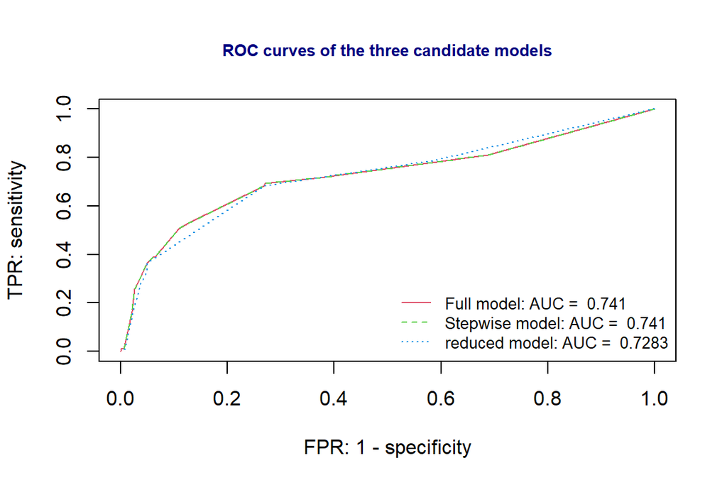

```r
pred01 = predict.glm(candidate01, newdata = train, type="response")
pred02 = predict.glm(candidate02, newdata = train, type="response")
pred03 = predict.glm(candidate03, newdata = train, type="response")
####
## ROC curve
 plot(TPR.FPR(pred01)[,1], TPR.FPR(pred01)[,2],
      type="l", col=2, lty=1, xlim=c(0,1), ylim=c(0,1),
      xlab = "FPR: 1 - specificity",
      ylab ="TPR: sensitivity",
      main = "ROC curves of the three candidate models",
      cex.main = 0.8,
      col.main = "navy")
 lines(TPR.FPR(pred02)[,1], TPR.FPR(pred02)[,2],  col=3, lty=2)
 lines(TPR.FPR(pred03)[,1], TPR.FPR(pred03)[,2],  col=4, lty=3)

  ##
  category = train$y == 1
  ROCobj01 <- roc(category, as.vector(pred01))
  ROCobj02 <- roc(category, as.vector(pred02))
  ROCobj03 <- roc(category, as.vector(pred03))
  AUC01 = round(auc(ROCobj01),4)
  AUC02 = round(auc(ROCobj02),4)
  AUC03 = round(auc(ROCobj03),4)
  ##
  legend("bottomright", c(paste("Full model: AUC = ",AUC01),
                         paste("Stepwise model: AUC = ",AUC02),
                         paste("reduced model: AUC = ", AUC03)),
        col=2:4, lty=1:3, cex = 0.8, bty="n")
```

We can see from the ROC curve that full model and the stepwise model are better than the reduced model. However, the full model and the stepwise model have similar ROC curve and AUCs. Since stepwise model is simpler than the full model, therefore, the final model to report is the stepwise model.

The accuracy measure of the stepwise model based one the test data has been reported in the earlier section.

# 9 Summary and Conclusion